# Color in R Plots

David Asare Kumi

June 12, 2019

## Part 1

### Plotting and color

- There are functions in R and in external packages that are very handy.
1. color 1 is Black.
2. color 2 is Red.
3. color 3 is Green.
- Default Image Plots in R from volcanoes.
1. heat.colors()
2. topo.colors()
- The grDevices package has two functions.
1. colorRamp.
2. colorRampPalette.
- The function colors() lists the names of colors you can use in any plotting function.

## colorRamp

There are 256 total numbers that you can specify for each color. colorRamp take a palette of colors and return a function that takes values between 0 and 1, indicating the extremes of the color palette (e.g see the “gray” function).

```r
pal <-colorRamp(c("red","blue"))
pal(0)
```

```
##      [,1] [,2] [,3]
## [1,]  255    0    0
```

```r
pal(1)
```

```
##      [,1] [,2] [,3]
## [1,]    0    0  255
```

```r
pal(0.5)
```

```
##       [,1] [,2]  [,3]
## [1,] 127.5    0 127.5
```

```r
pal(seq(0,1,len=10))
```

```
##            [,1] [,2]      [,3]
##  [1,] 255.00000    0   0.00000
##  [2,] 226.66667    0  28.33333
##  [3,] 198.33333    0  56.66667
##  [4,] 170.00000    0  85.00000
##  [5,] 141.66667    0 113.33333
##  [6,] 113.33333    0 141.66667
##  [7,]  85.00000    0 170.00000
##  [8,]  56.66667    0 198.33333
##  [9,]  28.33333    0 226.66667
## [10,]   0.00000    0 255.00000
```

## colorRampPalette

colorRampPalette takes a palette of colors and return a function that takes integer arguments and returns a vector of colors interpolating the palette (like heat.colors or topo.colors).

```r
pal <-colorRampPalette(c("red","yellow"))
pal(2) #hexadecimal
```

```
## [1] "#FF0000" "#FFFF00"
```

## There are 3 types of palettes

- Sequencial - for ordered data.
- Diverging - data that can deviate.
- Qualitative - data that are not ordered (factors,categorical)

## RColorBrewer and colorRampPalette

```r
library(RColorBrewer)
cols <-brewer.pal(3,"BuGn")
cols
```

```
## [1] "#E5F5F9" "#99D8C9" "#2CA25F"
```

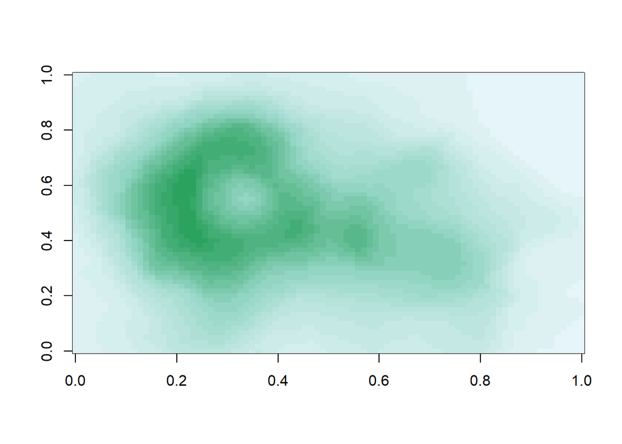

```r
pal <-colorRampPalette(cols)

image(volcano,col=pal(20))
```

## The Smooth Scatter function

Another function that uses the color brewer palette is the smooth scatter function. This is useful for plotting (scatter) of a lot of different points.

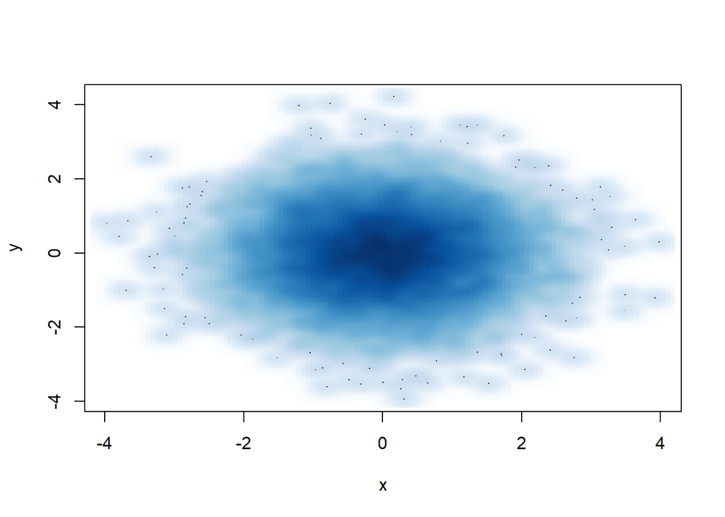

```r
x <-rnorm(10000)
y <-rnorm(10000)
smoothScatter(x,y) #The default color is the blues
```

## Some other Plotting Notes

- The rgb function can be used to produce any color via red,green,blue proportions.
- Color transparency can be added via the alpha parameter to rgb.
- The colorspace package can be used for a different control over colors.

## Scatterplot with no transparency and Scatterplot with transparency

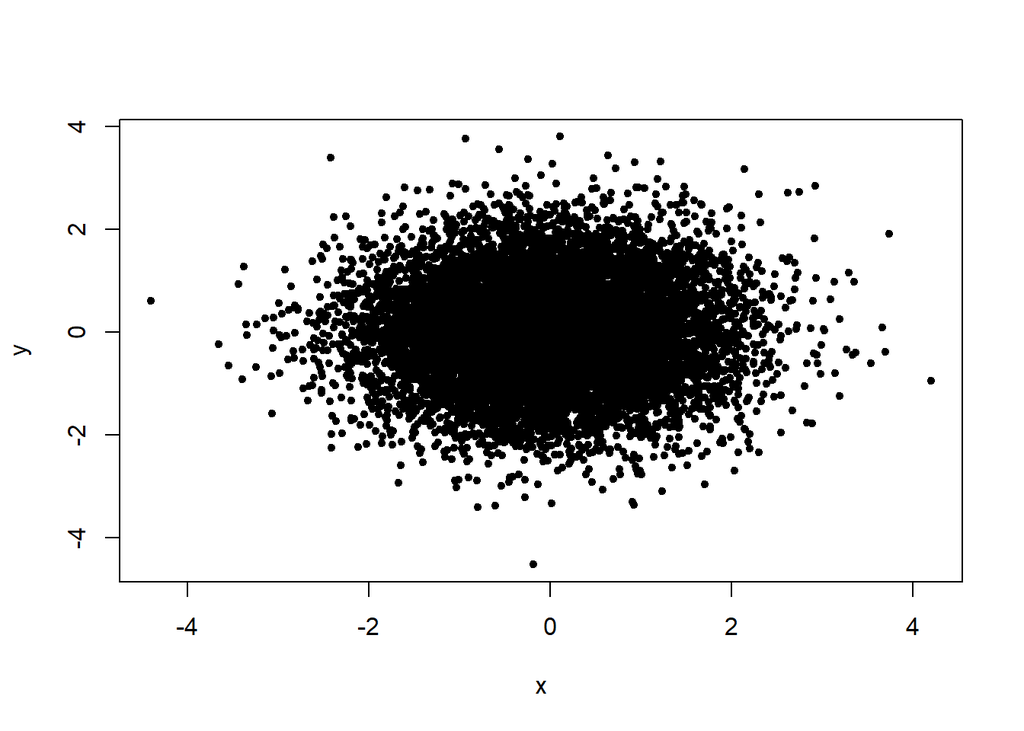

```r
x <-rnorm(10000)
y <-rnorm(10000)
plot(x,y,pch=20)
```

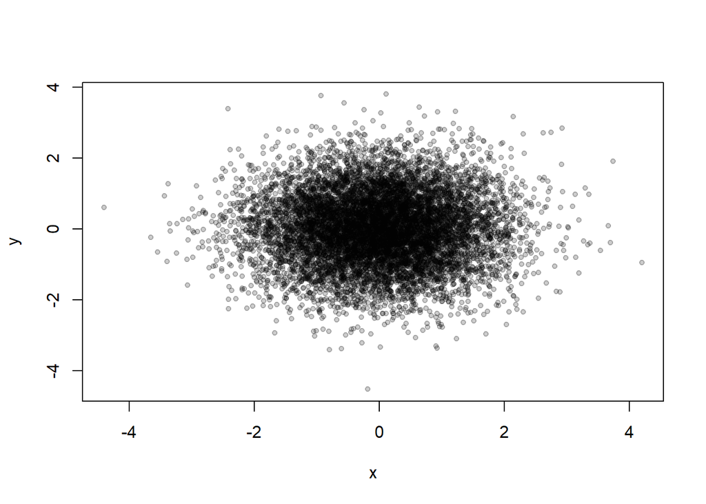

```r
#Scatterplot with transparency
plot(x,y,col=rgb(0,0,0,alpha=0.2),pch=20)
```